# Phasing

Harly Durbin

```r
knitr::opts_chunk$set(echo = TRUE, message = FALSE, warning = FALSE)
library(readr)
library(dplyr)
library(ggplot2)
library(purrr)
library(tidyr)
library(tidylog)
library(magrittr)
```

# Notes & questions

- Filter down to only sites with complete data? Remove sites with >= 10% missingness
- What genetic map?
  - 1 Mb/cM?
  - Yassine: “infer the map using the Li & Stephens (2003) LD based method”
  - Jared: “Use published 50K map”
- Sample sex determination?
  - PLINK sex check
  - `bcftools guess_ploidy`: need coordinates of PAR
    - (“The size of the PAR on the ARS-UCD1.2 reference genome assembly was 5,708,626 bp”)[https://www.journalofdairyscience.org/article/S0022-0302(19)30102-X/fulltext]
    - PAB at ChrX:133,300,518
  - Coverage on the sex chromosomes
    - True females may show coverage on Y due to mis-mapping of PAR?
  - Heterozygosity on the X

plink –vcf data/derived_data/joint_genotyping/remove_samples/remove_samples.X.vcf.gz –make-bed –double-id –cow –chr X -set-missing-var-ids @:#$1$2 –threads 12 –from-bp 1 –to-bp 133300518 –out test_x

plink –bfile test_x –double-id –cow –threads 12 –impute-sex –make-bed –out impute_sex

# Setup

```r
sample_metadata <- read_csv(here::here("data/derived_data/metadata/bovine_demo.sample_metadata.csv"))
```

```r
sex_cov <-
  read_rds(here::here("data/derived_data/metadata/coverage/cov_detail.rds")) %>%
  filter(chr %in% c("X", "Y")) %>%
  select(lab_id:mean, -total, -sid) %>%
  tidyr::pivot_wider(values_from = mean, names_from = chr) %>%
  right_join(sample_metadata %>%
               select(lab_id:sex, bio_sample, species, population, avg_coverage)) %>%
  select(lab_id, international_id, bio_sample, sex, population, species, everything()) %>%
  # I know already that my ancient samples are both males
  mutate(sex = if_else(population == "ancient", "M", sex))
```

# Sex determination

## How many samples with no sex listed?

```r
sex_cov %>%
  filter(is.na(sex)) %>%
  group_by(population) %>%
  tally(sort = TRUE)
```

| population | n |
| --- | --- |
| brown swiss | 87 |
| holstein | 68 |
| yak qtp | 60 |
| braunvieh | 37 |
| qinchuan | 37 |
| simmental | 25 |
| hanwoo | 21 |
| yak datong | 20 |
| normande | 18 |
| red angus | 18 |

[output cut: 59 more lines]

## Based on coverage of sex chromosomes

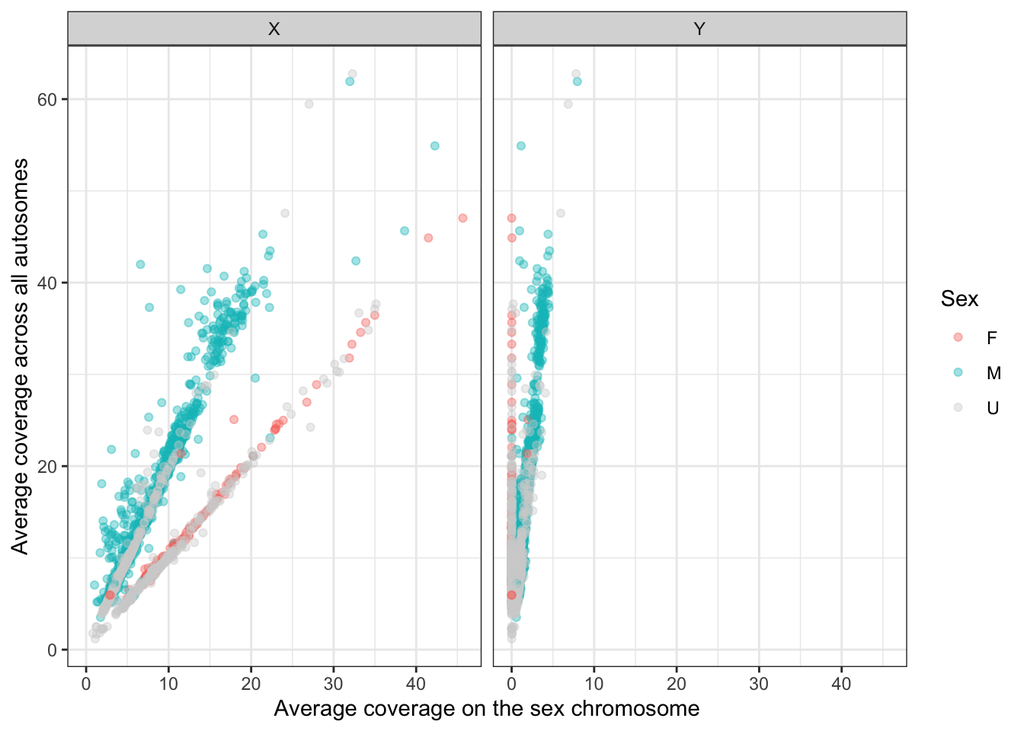

```r
sex_cov %>%
  tidyr::pivot_longer(cols = c("X", "Y"), names_to = "chr") %>%
  mutate(sex = if_else(is.na(sex), "U", sex)) %>%
  ggplot(aes(x = value, y = avg_coverage, color = sex)) +
  geom_point(alpha = 0.4) +
  scale_color_manual(values = c("F" = "#F8766D",
                                "M" = "#00BFC4",
                                "U" = "lightgrey")) +
  theme_bw() +
  labs(x = "Average coverage on the sex chromosome", y = "Average coverage across all autosomes", color = "Sex") +
  facet_wrap(~ chr)
```

```r
#ggsave(here::here("figures/phasing/xy_cov.all.png"))
```

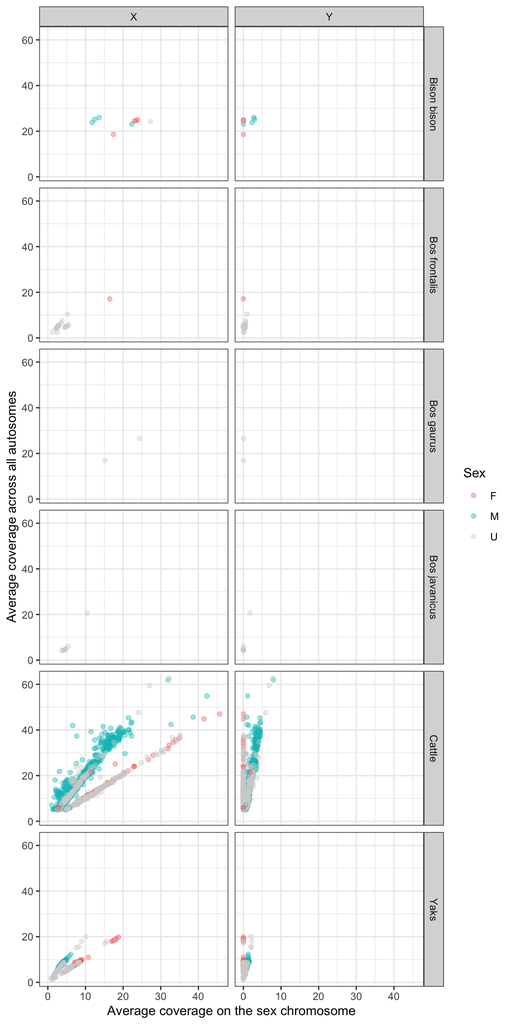

```r
sex_cov %>%
  tidyr::pivot_longer(cols = c("X", "Y"), names_to = "chr") %>%
  mutate(sex = if_else(is.na(sex), "U", sex),
         species_group =
           case_when(
             species %in% c("bos primigenius", "bos taurus", "composite", "bos indicus") ~ "Cattle",
             species %in% c("bos grunniens", "bos mutus") ~ "Yaks",
             TRUE ~ stringr::str_to_sentence(species)
           )) %>%
  ggplot(aes(x = value, y = avg_coverage, color = sex)) +
  geom_point(alpha = 0.4) +
  scale_color_manual(values = c("F" = "#F8766D",
                                "M" = "#00BFC4",
                                "U" = "lightgrey")) +
  theme_bw() +
  labs(x = "Average coverage on the sex chromosome", y = "Average coverage across all autosomes", color = "Sex") +
  facet_grid(species_group ~ chr)
```

```r
#ggsave(here::here("figures/phasing/xy_cov.all.png"))
```

### Correlation between X coverage, Y coverage, and autosomal coverage

#### Known females

```r
sex_cov %>%
  filter(sex == "F") %>%
  select(X, Y, avg_coverage) %>%
  corrr::correlate(diagonal = 1)
```

| rowname | X | Y | avg_coverage |
| --- | --- | --- | --- |
| X | 1.0000000 | -0.16061621 | 0.98098173 |
| Y | -0.1606162 | 1.00000000 | 0.02051225 |
| avg_coverage | 0.9809817 | 0.02051225 | 1.00000000 |

#### Known males

```r
sex_cov %>%
  filter(sex == "M") %>%
  select(X, Y, avg_coverage) %>%
  corrr::correlate(diagonal = 1)
```

| rowname | X | Y | avg_coverage |
| --- | --- | --- | --- |
| X | 1.0000000 | 0.8837458 | 0.9552308 |
| Y | 0.8837458 | 1.0000000 | 0.9206851 |
| avg_coverage | 0.9552308 | 0.9206851 | 1.0000000 |

### Assign likely sex based on (mean coverage on X or Y/mean coverage on autosomes)

```r
sex_cov %>%
  filter(!is.na(sex)) %>%
  mutate(y_vs_auto = Y / avg_coverage,
         x_vs_auto = X / avg_coverage) %>%
  group_by(sex) %>%
  summarise(
    `Mean (Y/autosomes)` = mean(y_vs_auto),
    `Mean (X/autosomes)` = mean(x_vs_auto),
    `SD (Y/autosomes)` = sd(y_vs_auto),
    `SD (X/autosomes)` = sd(x_vs_auto)
  ) %>%
  select(Sex = sex, contains("X/"), contains("Y/"))
```

| Sex | Mean (X/autosomes) | SD (X/autosomes) | Mean (Y/autosomes) | SD (Y/autosomes) |
| --- | --- | --- | --- | --- |
| F | 0.9172331 | 0.12504436 | 0.008334149 | 0.02969766 |
| M | 0.4928928 | 0.07027791 | 0.101765483 | 0.02238835 |

```r
sample_metadata %<>%
  mutate(sex = if_else(is.na(sex), "U", sex)) %>%
  left_join(
    sex_cov %>%
      mutate(
        y_vs_auto = Y / avg_coverage,
        x_vs_auto = X / avg_coverage,
        sex_cov =
          case_when(x_vs_auto >= (0.9172331 - 0.12504436) ~ "F",
                    TRUE ~ "M")
      ) %>%
      select(international_id, sex_cov, x_vs_auto, y_vs_auto)
  )
```

## Based on `bcftools +guess-ploidy`

```r
sample_metadata %<>%
  left_join(purrr::map(.x = c("GT", "PL"), ~ read_table2(
    here::here(
      glue::glue(
        "data/derived_data/joint_genotyping/impute_sex/bovine_demo.guess_ploidy.{.x}.txt"
      )
    ),
    col_names = c("international_id", glue::glue("sex_{.x}"))
  )) %>%
    reduce(full_join))
```

## Based on X chromosome heterozygosity using `plink --impute-sex`

```r
sample_metadata %<>%
  left_join(
    read_table2(
      here::here(
        "data/derived_data/joint_genotyping/impute_sex/impute_sex.sexcheck"
      )
    ) %>%
      janitor::clean_names() %>%
      select(international_id = fid, sex_het = snpsex, f) %>%
      mutate(sex_het =
               case_when(
                 sex_het == 0 ~ "U",
                 sex_het == 1 ~ "M",
                 sex_het == 2 ~ "F"
               ))
  )
```

## Final determination based on all available information

```r
sample_metadata %<>%
  select(international_id, contains("sex"), x_vs_auto, y_vs_auto, f, everything())
```

- Quite a few `GT` inferred sexes disagree with other lines of evidence

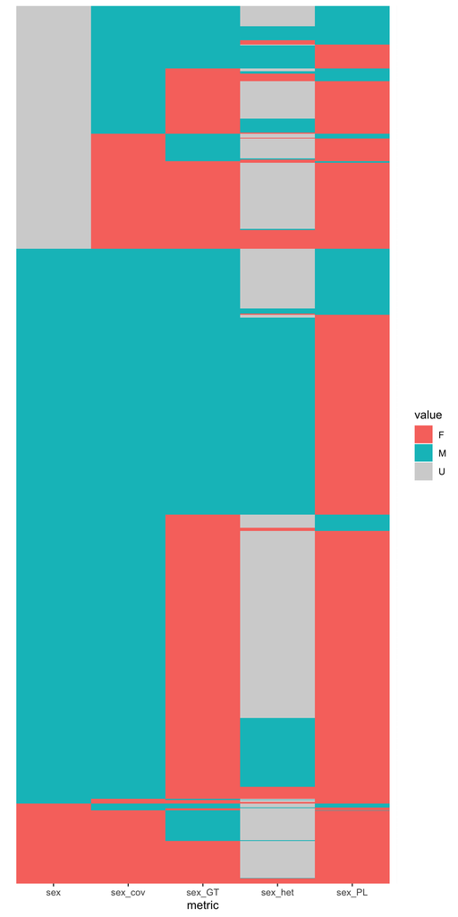

```r
sample_metadata %>%
  arrange(sex, sex_cov, sex_GT, sex_PL, sex_het) %>%
  mutate(international_id = forcats::fct_inorder(international_id)) %>%
  select(international_id, contains("sex")) %>%
  tidyr::pivot_longer(cols = contains("sex"), names_to = "metric") %>%
  ggplot(aes(x = metric, y = international_id, fill = value)) +
  geom_tile() +
  scale_fill_manual(values = c("F" = "#F8766D",
                                "M" = "#00BFC4",
                                "U" = "lightgrey")) +
  theme(axis.text.y = element_blank(),
        axis.ticks.y = element_blank(),
        axis.title.y = element_blank())
```

```r
ggsave(here::here("figures/phasing/sex_consensus.png"))
```

```r
sample_metadata %>%
  filter(x_vs_auto > 0.8) %>%
  filter(sex == "M") %>%
  pull(international_id) %>%
  datapasta::vector_construct()
```

```
## [1] "c(\"SIMDEUF000938065319\", \"UMCUSAM000000020087\", \"UMCUSAM000000033784\", \"UMCUSAM000000196770\", \"UMCUSAM000000198523\", \"UMCUSAM000000202633\", \"UMCUSAM000000204540\", \"UMCUSAM000000204542\", \"UMCUSAU000000194531\", \"UMCUSAU000000194532\", \"UMCUSAU000000194533\", \"UMCUSAU000000…
```

```r
sample_metadata %>%
  filter(0.55 > x_vs_auto) %>%
  filter(sex == "F")
```

| international_id | sex | sex_cov | sex_GT | sex_PL | sex_het | x_vs_auto | y_vs_auto | f | lab_id | bio_sample | population | region | continent | species | avg_coverage | owner |
| --- | --- | --- | --- | --- | --- | --- | --- | --- | --- | --- | --- | --- | --- | --- | --- | --- |
| UMCUSAF000000033534 | F | M | M | M | U | 0.5283569 | 0.088752869 | 0.5595 | 33534 | NA | gir | india and pakistan | asia | bos indicus | 7.211034 | NA |
| UMCUSAF000000033539 | F | M | F | F | U | 0.5172014 | 0.083649923 | 0.2267 | 33539 | NA | gir | india and pakistan | asia | bos indicus | 9.802759 | NA |
| UMCUSAF000000087104 | F | M | F | F | U | 0.5032875 | 0.094227829 | 0.6959 | 87104 | NA | holstein | continental europe | europe | bos taurus | 9.020690 | NA |
| UMCUSAF000000199739 | F | M | F | F | U | 0.5189463 | 0.114245652 | 0.7544 | 199739 | SAMN10693932 | angus | british isles | europe | bos taurus | 10.328621 | University of Nebraska Lincoln |
| UMCUSAF000000199748 | F | M | F | F | U | 0.5216560 | 0.118815358 | 0.6585 | 199748 | SAMN10721585 | boskarin | podolian steppe | europe | bos taurus | 8.837241 | Wageningen University and Research |
| UMCUSAF000000202696 | F | M | M | M | U | 0.4189857 | 0.143411229 | 0.2202 | 202696 | SAMN09737122 | yak jinchuan | asian steppe | asia | bos grunniens | 7.112414 | Southwest Minzu University |
| UMCUSAF000000202719 | F | M | M | M | U | 0.4986327 | 0.128563142 | 0.5196 | 202719 | SAMN09737145 | yak jinchuan | asian steppe | asia | bos grunniens | 8.322759 | Southwest Minzu University |
| UMCUSAF000000202736 | F | M | M | M | U | 0.4828545 | 0.135906424 | 0.5547 | 202736 | SAMN09737162 | yak jinchuan | asian steppe | asia | bos grunniens | 9.050345 | Southwest Minzu University |
| UMCUSAF000000202748 | F | M | M | M | U | 0.4892886 | 0.130725969 | 0.4714 | 202748 | SAMN09737174 | yak jinchuan | asian steppe | asia | bos grunniens | 8.032069 | Southwest Minzu University |
| UMCUSAF000000202749 | F | M | M | M | U | 0.4723659 | 0.130589270 | 0.5703 | 202749 | SAMN09737175 | yak jinchuan | asian steppe | asia | bos grunniens | 9.801724 | Southwest Minzu University |

[output cut: 6 more lines]

```r
sample_metadata %>%
  mutate(imputed_sex =
           case_when(
             international_id %in% c("SIMDEUF000938065319", "UMCUSAM000000020087", "UMCUSAM000000033784", "UMCUSAM000000196770", "UMCUSAM000000198523", "UMCUSAM000000202633", "UMCUSAM000000204540", "UMCUSAM000000204542", "UMCUSAU000000194531", "UMCUSAU000000194532", "UMCUSAU000000194533", "UMCUSAU000000194535", "UMCUSAU000000194704") ~ "F",
             international_id %in% c("UMCUSAU000000205014") ~ "M",
             !is.na(sex) ~ sex,
             TRUE ~ sex_cov
           ))
```

| international_id | sex | sex_cov | sex_GT | sex_PL | sex_het | x_vs_auto | y_vs_auto | f | lab_id | bio_sample | population | region | continent | species | avg_coverage | owner | imputed_sex |
| --- | --- | --- | --- | --- | --- | --- | --- | --- | --- | --- | --- | --- | --- | --- | --- | --- | --- |
| A2494_Yenisei_River | U | M | M | M | M | 0.4725788 | 0.0770396520 | 0.85450 | 118017 | NA | ancient | asian steppe | asia | bos primigenius | 19.340690 | NA | U |
| AANAUSM000000AG0152 | M | M | F | F | U | 0.4278075 | 0.0877005348 | 0.57510 | 198286 | SAMN05803886 | angus lowline | british isles | europe | bos taurus | 9.350000 | Department of Economic Development, Jobs, Transport and Resources | M |
| AANAUSM000000AG0154 | M | M | F | F | U | 0.3982833 | 0.0838491077 | 0.30580 | 198287 | SAMN05803887 | angus lowline | british isles | europe | bos taurus | 7.632759 | Department of Economic Development, Jobs, Transport and Resources | M |
| AANCANM000000561205 | M | M | F | F | U | 0.5629203 | 0.0901263501 | 0.71560 | 107960 | SAMN02142982 | angus | british isles | europe | bos taurus | 6.768276 | Livestock Gentec, University of Alberta | M |
| AANCANM000000583665 | M | M | F | M | U | 0.5113666 | 0.0827210649 | 0.71130 | 108019 | SAMN02842714 | angus | british isles | europe | bos taurus | 7.978621 | Livestock Gentec, University of Alberta | M |
| AANCANM000000631887 | M | M | M | F | M | 0.5122247 | 0.0974088292 | 0.89230 | 108110 | SAMN02843152 | angus | british isles | europe | bos taurus | 15.091034 | Livestock Gentec, University of Alberta | M |
| AANCANM000000912768 | M | M | F | F | U | 0.4702534 | 0.0840850515 | 0.29890 | 107940 | SAMN01915341 | angus | british isles | europe | bos taurus | 6.422069 | Livestock Gentec, University of Alberta | M |
| AANCANM000000976295 | M | M | F | F | U | 0.5190122 | 0.0924057355 | 0.43020 | 107938 | SAMN01915339 | angus | british isles | europe | bos taurus | 6.493103 | Livestock Gentec, University of Alberta | M |
| AANCANM000001047219 | M | M | M | F | M | 0.5177503 | 0.0950206398 | 0.87200 | 108099 | SAMN02843141 | angus | british isles | europe | bos taurus | 13.365517 | Livestock Gentec, University of Alberta | M |
| AANCANM000001067384 | M | M | F | F | U | 0.5151467 | 0.0947501983 | 0.79960 | 108047 | SAMN02843079 | angus | british isles | europe | bos taurus | 10.870690 | Livestock Gentec, University of Alberta | M |

[output cut: 990 more lines]